# Modeling

Keith Colella

2023-03-19

## Introduction

This work is the fifth of five stages of an analysis where the main objective was to identify the most valued data science skills. Our approach to this was to collect job postings from various job boards and extract the skills from the postings. In this final section, we construct a three models that attempt to use the data we’ve collected to (i) predict the salary and (ii) find job recommendations for a hypothetical job-seeker. These models are exploratory in nature. We recognize that, with regards to specification, best practices have not been employed and key assumptions have not been assessed. Still, we constructed the following models as proofs of concept on how our data might be used to inform career-related decisions. The final two models (Random Forest and KNN) are used in Shiny apps to explore the interaction between inputs and outputs. These apps can be accessed at the following links.  
1. https://kac624.shinyapps.io/rf_salary_prediction/  
2. https://kac624.shinyapps.io/data_science_job_recommender/

## Read in Data

We load in our previously constructed data frames. The `jobs_long` dataframe contains all jobs listings and associated skills. It’s in the “long” format, so it contains significant duplication. The `job_listing` dataframe contains the same information but without the skills. As a result, there is no duplication, and each row constitutes a single observation (i.e. a single job listing).

```r
jobs_long <- read_csv('output/job_listings_skills_long.csv')
job_listings <- read_csv('output/job_listings_enhanced.csv') %>%
  select(-job_quals, -job_description)
```

## Simple OLS

We need to use the is.na() function to check for missing or invalid values in each variable individually

```r
sum(is.na(job_listings$salary_max))
```

```
## [1] 359
```

```r
sum(is.na(job_listings$years_exp))
```

```
## [1] 2385
```

Using mean imputation to replace the missing values with the mean value of the corresponding variable. We recognize the potential for mean imputation to skew data, but for the sake of exploration and maintaining the volume of data, we choose to impute.

```r
# Replace missing values in years_exp with the mean value
job_listings$years_exp[is.na(job_listings$years_exp)] <- mean(job_listings$years_exp, na.rm = TRUE)

# Replace missing values in salary_max with the mean value
job_listings$salary_max[is.na(job_listings$salary_max)] <- mean(job_listings$salary_max, na.rm = TRUE)
```

A scatter plot and linear regression line, along with box plots for categorical variables.

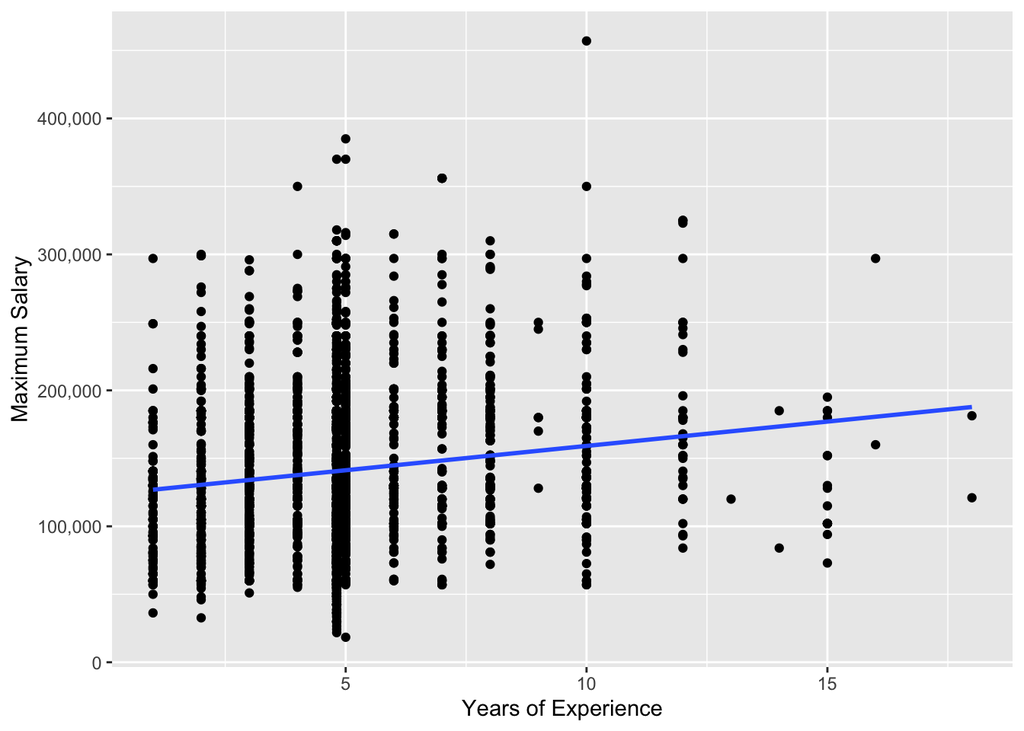

```r
ggplot(job_listings, aes(x = years_exp, y = salary_max)) +
  geom_point() +
  geom_smooth(method = "lm", se = FALSE) +
  labs(x = "Years of Experience", y = "Maximum Salary") +
  scale_y_continuous(label = scales::comma)
```

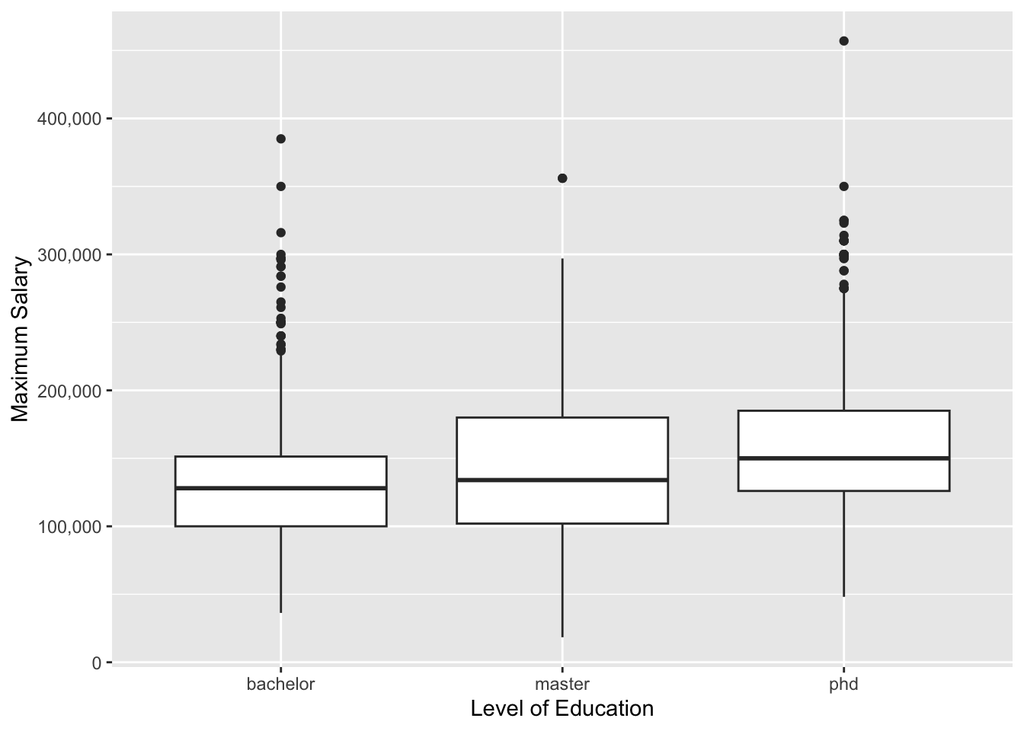

```r
job_listings %>%
  filter(!is.na(highest_ed)) %>%
  ggplot(aes(highest_ed, salary_max)) +
  geom_boxplot() +
  labs(x = "Level of Education", y = "Maximum Salary") +
  scale_y_continuous(label = scales::comma)
```

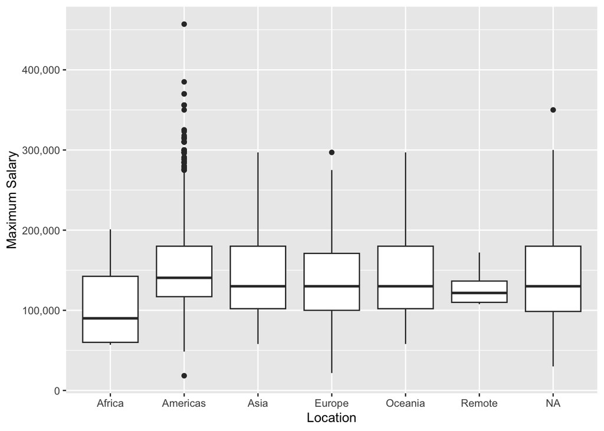

```r
job_listings %>%
  ggplot(aes(continent, salary_max)) +
  geom_boxplot() +
  labs(x = "Location", y = "Maximum Salary") +
  scale_y_continuous(label = scales::comma)
```

We then fit our model and review results.

```r
ols <- lm(salary_max ~ highest_ed + years_exp + continent, data = job_listings)
summary(ols)
```

```
##
## Call:
## lm(formula = salary_max ~ highest_ed + years_exp + continent,
##     data = job_listings)
##
## Residuals:
##     Min      1Q  Median      3Q     Max
## -126659  -33581   -5905   31043  274155
##
## Coefficients:
##                   Estimate Std. Error t value Pr(>|t|)
## (Intercept)        77794.0     9266.3   8.395  < 2e-16 ***
## highest_edmaster    9999.4     2537.4   3.941 8.38e-05 ***
## highest_edphd      32528.1     2735.7  11.890  < 2e-16 ***
## years_exp           3051.4      500.1   6.101 1.24e-09 ***
## continentAmericas  42008.9     9068.2   4.633 3.83e-06 ***
## continentAsia      37805.0     9372.3   4.034 5.68e-05 ***
## continentEurope    23001.6     9296.2   2.474  0.01343 *
## continentOceania   46449.3    15355.2   3.025  0.00252 **
## continentRemote     5198.9    48991.8   0.106  0.91550
## ---
## Signif. codes:  0 '***' 0.001 '**' 0.01 '*' 0.05 '.' 0.1 ' ' 1
##
## Residual standard error: 48140 on 2155 degrees of freedom
##   (2606 observations deleted due to missingness)
## Multiple R-squared:  0.1155, Adjusted R-squared:  0.1122
## F-statistic: 35.17 on 8 and 2155 DF,  p-value: < 2.2e-16
```

```r
ols <- lm(salary_max ~ highest_ed +  years_exp, data = job_listings)
summary(ols)
```

```
##
## Call:
## lm(formula = salary_max ~ highest_ed + years_exp, data = job_listings)
##
## Residuals:
##     Min      1Q  Median      3Q     Max
## -119770  -34715   -4388   32934  278187
##
## Coefficients:
##                  Estimate Std. Error t value Pr(>|t|)
## (Intercept)      116972.7     2895.2  40.402  < 2e-16 ***
## highest_edmaster   5677.8     2468.5   2.300   0.0215 *
## highest_edphd     30801.7     2713.2  11.352  < 2e-16 ***
## years_exp          3103.9      499.5   6.213 6.17e-10 ***
## ---
## Signif. codes:  0 '***' 0.001 '**' 0.01 '*' 0.05 '.' 0.1 ' ' 1
##
## Residual standard error: 49170 on 2229 degrees of freedom
##   (2537 observations deleted due to missingness)
## Multiple R-squared:  0.08379,    Adjusted R-squared:  0.08255
## F-statistic: 67.95 on 3 and 2229 DF,  p-value: < 2.2e-16
```

```r
test <- data.frame(highest_ed = c('bachelor','master','phd'),
                   years_exp = c(5,10,15))

scales::comma(predict(ols, test))
```

```
##         1         2         3
## "132,492" "153,689" "194,332"
```

## Random Forest

Random Forest Regression requires numeric data, so categorical variables are one-hot encoded, i.e. converted to binary dummy variables. We also remove variables that won’t be used for prediction (job title, currency, website) and focus only on continent for location-related variables. We also convert the skills to a wide, dummy-encoded format, but rather than keep all 300+ skills as columns, we focus only on those skills that are cited more than 1000 times. We take these top ~20 skills as the most important.

We are left with a matrix of all numeric data.

```r
jobs_skills_matrix <- jobs_long %>%
  pivot_wider(names_from = highest_ed, values_from = highest_ed,
              names_prefix = 'ed_', values_fill = 0, values_fn = length) %>%
  pivot_wider(names_from = continent, values_from = continent,
              names_prefix = 'loc_', values_fill = 0, values_fn = length) %>%
  pivot_wider(names_from = skill, values_from = skill,
              values_fill = 0, values_fn = length) %>%
  column_to_rownames(., var = 'job_id') %>%
  select_if(is.numeric) %>%
  select(salary_max,
         years_exp,
         starts_with('ed_'),
         starts_with('loc_'),
         which(colSums(., na.rm = TRUE) > 1000),
         -ed_NA,
         -loc_NA,
         -salary_min)

colnames(jobs_skills_matrix) <- str_replace_all(
  colnames(jobs_skills_matrix),' ', '_')

head(jobs_skills_matrix)
```

```
##       salary_max years_exp ed_phd ed_master ed_bachelor loc_Americas loc_Europe
## 40879     110000         5      0         0           0            0          0
## 40788      30000        NA      0         0           0            0          0
## 40787      30000        NA      0         0           0            0          0
## 40786      30000        NA      0         0           0            0          0
## 40785      30000        NA      0         0           0            0          0
## 40784      30000        NA      0         0           0            0          0
##       loc_Asia loc_Africa loc_Oceania loc_Remote Engineering Python SQL
## 40879        0          0           0          0           1      1   1
## 40788        0          0           0          0           0      0   0
## 40787        0          0           0          0           0      0   0
## 40786        0          0           0          0           0      0   0
## 40785        0          0           0          0           0      0   0
## 40784        0          0           0          0           0      0   0
##       Data_visualization Collaboration Tableau Research Computer_Science
```

[output cut: 20 more lines]

Typically, random forest models requires iterative hyperparameter tuning to minimize error. For the sake of this exercise, we use the `randomForest` package’s default settings and go with the “out-of-the-box” approach.

```r
rf <- randomForest(salary_max ~ .,
                   data = jobs_skills_matrix,
                   ntree = 1000,
                   na.action = na.omit,
                   importance = TRUE)
rf
```

```
##
## Call:
##  randomForest(formula = salary_max ~ ., data = jobs_skills_matrix,      ntree = 1000, importance = TRUE, na.action = na.omit)
##                Type of random forest: regression
##                      Number of trees: 1000
## No. of variables tried at each split: 10
##
##           Mean of squared residuals: 1771685019
##                     % Var explained: 33.08
```

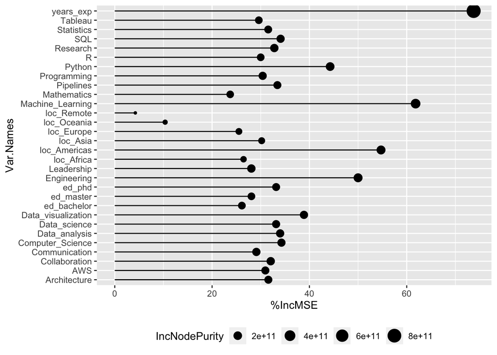

```r
imp <- as.data.frame(importance(rf))
imp$Var.Names <- row.names(imp)

ggplot(imp, aes(Var.Names, `%IncMSE`)) +
  geom_segment(aes(x = Var.Names, xend = Var.Names, y = 0, yend = `%IncMSE`)) +
  geom_point(aes(size = IncNodePurity)) +
  coord_flip() +
  theme(legend.position = 'bottom',
        panel.border = element_blank())
```

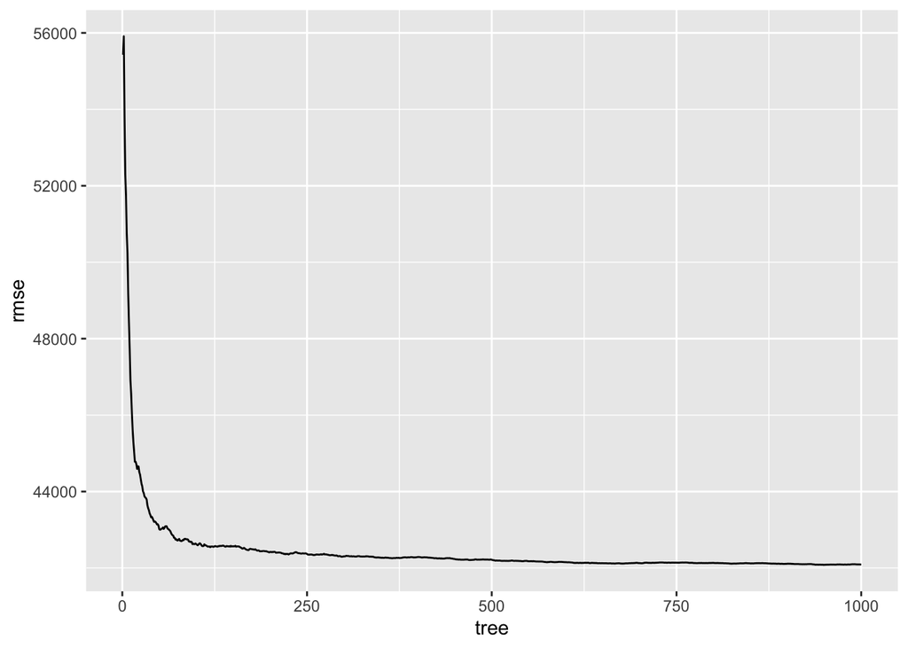

```r
data.frame(tree = 1:rf$ntree, rmse = sqrt(rf$mse)) %>%
  ggplot(aes(tree, rmse)) +
  geom_line()
```

We export our model and the matrix it used for usage in a Shiny app (saved under `salary_prediction`).

```r
saveRDS(rf, 'salary_prediction/salary_rf.rds')
write.csv(jobs_skills_matrix, 'salary_prediction/jobs_skills_matrix.csv', row.names = FALSE)
```

## KNN Recommender

Our final model will attempt to identify the k-nearest neighbors for a given job listing, meant to serve as recommendations for a hypothetical job seeker. We employ a very simple approach, constructing a matrix of Euclidean distances between listings based on base R’s `dist` function. The approach borrows from Ferran Martí’s knn example (see https://rpubs.com/ferranmt/80166).

We first calulate the distances, confirm the resuling matrix’s dimensions and take a sample of results. We confirm there are zeros along the diagonal, as expected, since the distance between matching jobs should be zero.

```r
jobs_distances <- as.matrix(dist(jobs_skills_matrix, method = 'euclidean'))
dim(jobs_distances)
```

```
## [1] 4769 4769
```

```r
jobs_distances[1:7,1:7]
```

```
##         40879    40788    40787    40786    40785    40784    41775
## 40879     0.0  81322.4  81322.4  81322.4  81322.4  81322.4  90000.0
## 40788 81322.4      0.0      0.0      0.0      0.0      0.0 172810.1
## 40787 81322.4      0.0      0.0      0.0      0.0      0.0 172810.1
## 40786 81322.4      0.0      0.0      0.0      0.0      0.0 172810.1
## 40785 81322.4      0.0      0.0      0.0      0.0      0.0 172810.1
## 40784 81322.4      0.0      0.0      0.0      0.0      0.0 172810.1
## 41775 90000.0 172810.1 172810.1 172810.1 172810.1 172810.1      0.0
```

Next, we construct a function to identify the k-nearest neighbors. The approach is straightforward. For a given job ID, a row from the above matrix is taken and converted to a dataframe with two columns: job ID and distance. That dataframe is then sorted in ascending order, and the top five job IDs (correlating to the five jobs with the lowest distance) are returned.

```r
knn <- function(i, distance_matrix, k = 5) {
  neighbors <- data.frame(dist = distance_matrix[i,])
  k_nearest_ids <- arrange(neighbors, dist) %>%
    slice(1:(k+1)) %>%
    rownames()
  return(k_nearest_ids)
}
```

Below is a sample of our recommendations will be returned in our final Shiny app. We use a random job from our current dataset as an test case (though in the app, users will enter details about a hypothetical job seeker). That test case is added to the jobs matrix, and (as above) Euclidean distances are calculated. We then feed the row associated with that test case into our previously constructed `knn` function to obtain the IDs for top five matches. We then grab the full details from the job_listings dataframe to present details to our user.

```r
test <- jobs_skills_matrix[100,]
new_matrix <- rbind(jobs_skills_matrix, test)
new_distances <- as.matrix(dist(new_matrix, method = 'euclidean'))
last_row_name <- rownames(tail(new_distances,1))
match_ids <- knn(last_row_name, new_distances, 5)
match_ids <- match_ids[match_ids != last_row_name]
match_ids
```

```
## [1] "41744" "41077" "39097" "39567" "40445"
```

```r
job_listings[job_listings$job_id %in% match_ids,]
```

```
## # A tibble: 5 × 11
##   job_id job_t…¹ locat…² salar…³ salar…⁴ salar…⁵ website highe…⁶ years…⁷ conti…⁸
##   <chr>  <chr>   <chr>   <chr>     <dbl>   <dbl> <chr>   <chr>     <dbl> <chr>
## 1 41744  insigh… United… USD       56000 105000  ai-job… <NA>       1    Europe
## 2 41077  insigh… United… USD       56000 105000  ai-job… <NA>       1    Europe
## 3 40445  data e… Lithua… USD       44520 140560. ai-job… <NA>       4.81 Europe
## 4 39567  data a… <NA>    USD       56000 105000  ai-job… <NA>       4.81 <NA>
## 5 39097  insigh… United… USD       56000 105000  ai-job… <NA>       1    Europe
## # … with 1 more variable: country <chr>, and abbreviated variable names
## #   ¹job_title, ²location, ³salary_currency, ⁴salary_min, ⁵salary_max,
## #   ⁶highest_ed, ⁷years_exp, ⁸continent
```

Finally, we save our data for use in the recommender Shiny app!

```r
write.csv(jobs_skills_matrix, 'job_recommendations/jobs_skills_matrix.csv', row.names = TRUE)
```